# 1.EDA

## Project Objective

Develop machine learning models to predict molecular toxicity across 12 biological assays using SMILES representations, enabling in-ico screening for drug discovery and chemical safety assessment.

## Dataset Overview

- **Source:** Tox21 Challenge Dataset
- **Size:** 7,831 molecules
- **Features:** SMILES strings
- **Targets:** 12 binary toxicity assays (NR and SR pathways)
- **Challenge:** High class imbalance (2-16% positive class) and missing labels (7-26%)

The final outcome is a set of optimized binary classification models that can predict toxic or non-toxic behavior of molecules for individual biological targets.

```python
# -- General --
import joblib
import os

# -- EDA and Preprocessing --
import pandas as pd
import numpy as np

# -- Visualization --
import seaborn as sns
import matplotlib.pyplot as plt

# -- RDKit --
from rdkit import Chem
from rdkit.Chem import Draw, rdMolDescriptors, Lipinski, Descriptors, Crippen
from rdkit import DataStructs
from rdkit.Chem.rdFingerprintGenerator import GetMorganGenerator

# -- Machine Learning --
from sklearn.model_selection import train_test_split
from sklearn.base import clone
from sklearn.ensemble import RandomForestClassifier
from xgboost import XGBClassifier
from sklearn.linear_model import LogisticRegression
from lightgbm import LGBMClassifier
from sklearn.neighbors import KNeighborsClassifier
from sklearn.pipeline import Pipeline

# -- Preprocessing --
from sklearn.preprocessing import PowerTransformer, StandardScaler

# -- Metrics --
from sklearn.metrics import f1_score, confusion_matrix, classification_report

import warnings

warnings.filterwarnings(
    "ignore",
    message="X does not have valid feature names",
    category=UserWarning
)
```

## 1. Loading Data

```python
# Loading Data
df_tox = pd.read_csv('../data/tox21.csv')
```

```python
print(f'The rows in the dataset are {df_tox.shape[0]} and the columns are {df_tox.shape[1]}!\n')
print(f'The columns in the dataset are:')

for no, col in enumerate(df_tox.columns, start=1):
    print(f'{no}. {col}')
```

```
The rows in the dataset are 7831 and the columns are 14!

The columns in the dataset are:
1. NR-AR
2. NR-AR-LBD
3. NR-AhR
4. NR-Aromatase
5. NR-ER
6. NR-ER-LBD
7. NR-PPAR-gamma
8. SR-ARE
9. SR-ATAD5
10. SR-HSE
11. SR-MMP
12. SR-p53
13. mol_id
14. smiles
```

### Tox21 Dataset Column Definitions

**Nuclear Receptor (NR) Pathways**

- **`NR-AR`**: Tests if a chemical affects the Androgen (male hormone) receptor.
- **`NR-AR-LBD`**: Tests if a chemical binds to the active site of the Androgen receptor.
- **`NR-AhR`**: Tests if a chemical acts like toxic environmental pollutants.
- **`NR-Aromatase`**: Tests if a chemical blocks estrogen formation.
- **`NR-ER`**: Tests if a chemical affects the Estrogen (female hormone) receptor.
- **`NR-ER-LBD`**: Tests if a chemical binds to the active site of the Estrogen receptor.
- **`NR-PPAR-gamma`**: Tests if a chemical affects fat and metabolism control.

**Stress Response (SR) Pathways**

- **`SR-ARE`**: Tests if a chemical causes oxidative (cell) stress.
- **`SR-ATAD5`**: Tests if a chemical damages DNA during replication.
- **`SR-HSE`**: Tests if a chemical causes protein stress or misfolding.
- **`SR-MMP`**: Tests if a chemical damages mitochondria (cell energy).
- **`SR-p53`**: Tests if a chemical triggers DNA damage response or cell death.

### 🔎 Key Observations

- The dataset contains 7,831 molecules, each identified by a unique `mol_id` and a corresponding `smiles` string.
- There are 12 toxicity assay columns, covering Nuclear Receptor (NR) and Stress Response (SR) pathways.
- The dataset structure is suitable for multi-target binary classification, where each assay is treated as an independent prediction task.

## 2. Data Inspection

```python
df_tox.shape
```

```
(7831, 14)
```

```python
df_tox.head()
```

|  | NR-AR | NR-AR-LBD | NR-AhR | NR-Aromatase | NR-ER | NR-ER-LBD | NR-PPAR-gamma | SR-ARE | SR-ATAD5 | SR-HSE | SR-MMP | SR-p53 | mol_id | smiles |
| --- | --- | --- | --- | --- | --- | --- | --- | --- | --- | --- | --- | --- | --- | --- |
| 0 | 0.0 | 0.0 | 1.0 | NaN | NaN | 0.0 | 0.0 | 1.0 | 0.0 | 0.0 | 0.0 | 0.0 | TOX3021 | CCOc1ccc2nc(S(N)(=O)=O)sc2c1 |
| 1 | 0.0 | 0.0 | 0.0 | 0.0 | 0.0 | 0.0 | 0.0 | NaN | 0.0 | NaN | 0.0 | 0.0 | TOX3020 | CCN1C(=O)NC(c2ccccc2)C1=O |
| 2 | NaN | NaN | NaN | NaN | NaN | NaN | NaN | 0.0 | NaN | 0.0 | NaN | NaN | TOX3024 | CC[C@]1(O)CC[C@H]2[C@@H]3CCC4=CCCC[C@@H]4[C@H]... |
| 3 | 0.0 | 0.0 | 0.0 | 0.0 | 0.0 | 0.0 | 0.0 | NaN | 0.0 | NaN | 0.0 | 0.0 | TOX3027 | CCCN(CC)C(CC)C(=O)Nc1c(C)cccc1C |
| 4 | 0.0 | 0.0 | 0.0 | 0.0 | 0.0 | 0.0 | 0.0 | 0.0 | 0.0 | 0.0 | 0.0 | 0.0 | TOX20800 | CC(O)(P(=O)(O)O)P(=O)(O)O |

```python
# Reordering columns
cols = df_tox.columns.tolist()
cols = ['mol_id', 'smiles'] + [c for c in cols if c != 'smiles' and c != 'mol_id']
df_tox = df_tox[cols]
```

```python
df_tox.head()
```

|  | mol_id | smiles | NR-AR | NR-AR-LBD | NR-AhR | NR-Aromatase | NR-ER | NR-ER-LBD | NR-PPAR-gamma | SR-ARE | SR-ATAD5 | SR-HSE | SR-MMP | SR-p53 |
| --- | --- | --- | --- | --- | --- | --- | --- | --- | --- | --- | --- | --- | --- | --- |
| 0 | TOX3021 | CCOc1ccc2nc(S(N)(=O)=O)sc2c1 | 0.0 | 0.0 | 1.0 | NaN | NaN | 0.0 | 0.0 | 1.0 | 0.0 | 0.0 | 0.0 | 0.0 |
| 1 | TOX3020 | CCN1C(=O)NC(c2ccccc2)C1=O | 0.0 | 0.0 | 0.0 | 0.0 | 0.0 | 0.0 | 0.0 | NaN | 0.0 | NaN | 0.0 | 0.0 |
| 2 | TOX3024 | CC[C@]1(O)CC[C@H]2[C@@H]3CCC4=CCCC[C@@H]4[C@H]... | NaN | NaN | NaN | NaN | NaN | NaN | NaN | 0.0 | NaN | 0.0 | NaN | NaN |
| 3 | TOX3027 | CCCN(CC)C(CC)C(=O)Nc1c(C)cccc1C | 0.0 | 0.0 | 0.0 | 0.0 | 0.0 | 0.0 | 0.0 | NaN | 0.0 | NaN | 0.0 | 0.0 |
| 4 | TOX20800 | CC(O)(P(=O)(O)O)P(=O)(O)O | 0.0 | 0.0 | 0.0 | 0.0 | 0.0 | 0.0 | 0.0 | 0.0 | 0.0 | 0.0 | 0.0 | 0.0 |

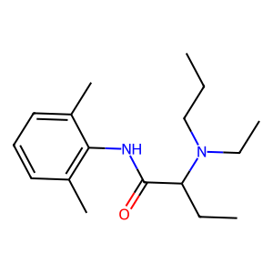

```python
# Example  of Visualization of a molecule from DataSet
mol = Chem.MolFromSmiles("CCCN(CC)C(CC)C(=O)Nc1c(C)cccc1C")
Draw.MolToImage(mol)
```

```python
df_tox.info()
```

```
<class 'pandas.core.frame.DataFrame'>
RangeIndex: 7831 entries, 0 to 7830
Data columns (total 14 columns):
 #   Column         Non-Null Count  Dtype
---  ------         --------------  -----
 0   mol_id         7831 non-null   object
 1   smiles         7831 non-null   object
 2   NR-AR          7265 non-null   float64
 3   NR-AR-LBD      6758 non-null   float64
 4   NR-AhR         6549 non-null   float64
 5   NR-Aromatase   5821 non-null   float64
 6   NR-ER          6193 non-null   float64
 7   NR-ER-LBD      6955 non-null   float64
 8   NR-PPAR-gamma  6450 non-null   float64
 9   SR-ARE         5832 non-null   float64
 10  SR-ATAD5       7072 non-null   float64
 11  SR-HSE         6467 non-null   float64
 12  SR-MMP         5810 non-null   float64
 13  SR-p53         6774 non-null   float64
dtypes: float64(12), object(2)
memory usage: 856.6+ KB
```

```python
df_tox.columns
```

```
Index(['mol_id', 'smiles', 'NR-AR', 'NR-AR-LBD', 'NR-AhR', 'NR-Aromatase',
       'NR-ER', 'NR-ER-LBD', 'NR-PPAR-gamma', 'SR-ARE', 'SR-ATAD5', 'SR-HSE',
       'SR-MMP', 'SR-p53'],
      dtype='object')
```

```python
target_columns = ['NR-AR', 'NR-AR-LBD', 'NR-AhR', 'NR-Aromatase',
                  'NR-ER', 'NR-ER-LBD', 'NR-PPAR-gamma', 'SR-ARE',
                  'SR-ATAD5', 'SR-HSE', 'SR-MMP', 'SR-p53']

summary = pd.DataFrame({
    "null_count": df_tox[target_columns].isna().sum(),
    "non_null_count": df_tox[target_columns].notna().sum(),
    "null_%": (df_tox[target_columns].isna().mean() * 100).round(2),

    # class counts (ignore NaNs automatically)
    "count_0": (df_tox[target_columns] == 0).sum(),
    "count_1": (df_tox[target_columns] == 1).sum(),

    # percentage of positive class
    "%_ones": ((df_tox[target_columns] == 1).sum()
                / df_tox[target_columns].notna().sum()
                * 100).round(2)

}).sort_values("null_count", ascending=False)

summary
```

|  | null_count | non_null_count | null_% | count_0 | count_1 | %_ones |
| --- | --- | --- | --- | --- | --- | --- |
| SR-MMP | 2021 | 5810 | 25.81 | 4892 | 918 | 15.80 |
| NR-Aromatase | 2010 | 5821 | 25.67 | 5521 | 300 | 5.15 |
| SR-ARE | 1999 | 5832 | 25.53 | 4890 | 942 | 16.15 |
| NR-ER | 1638 | 6193 | 20.92 | 5400 | 793 | 12.80 |
| NR-PPAR-gamma | 1381 | 6450 | 17.64 | 6264 | 186 | 2.88 |
| SR-HSE | 1364 | 6467 | 17.42 | 6095 | 372 | 5.75 |
| NR-AhR | 1282 | 6549 | 16.37 | 5781 | 768 | 11.73 |
| NR-AR-LBD | 1073 | 6758 | 13.70 | 6521 | 237 | 3.51 |
| SR-p53 | 1057 | 6774 | 13.50 | 6351 | 423 | 6.24 |
| NR-ER-LBD | 876 | 6955 | 11.19 | 6605 | 350 | 5.03 |
| SR-ATAD5 | 759 | 7072 | 9.69 | 6808 | 264 | 3.73 |
| NR-AR | 566 | 7265 | 7.23 | 6956 | 309 | 4.25 |

```python
df_tox.columns
```

```
Index(['mol_id', 'smiles', 'NR-AR', 'NR-AR-LBD', 'NR-AhR', 'NR-Aromatase',
       'NR-ER', 'NR-ER-LBD', 'NR-PPAR-gamma', 'SR-ARE', 'SR-ATAD5', 'SR-HSE',
       'SR-MMP', 'SR-p53'],
      dtype='object')
```

```python
df_tox['smiles'].duplicated().sum()
```

```
np.int64(0)
```

### 🔎 Key Observations

- Each assay is a binary label where:
  - `0` indicates non-toxic (inactive)
  - `1` indicates toxic (active)
- All assay columns contain missing values, indicating that not every molecule was tested against every biological target.
- The percentage of missing values varies across assays, with some targets having more than 25% missing data.
- The class distribution is highly imbalanced:
  - Most molecules are labeled as non-toxic (0)
  - Toxic (1) samples are comparatively rare
- This imbalance highlights the need for appropriate evaluation metrics (F1 score) and balanced learning strategies during modeling.

## 3. Feature Engineering

```python
def calculate_descriptors_safe(smiles):
    """
    Calculates multiple molecular descriptors from a SMILES string.
    Returns a pandas Series so it can add multiple columns at once.
    Output schema is IDENTICAL to the original function.
    """
    morgan_gen = GetMorganGenerator(radius=3, fpSize=2048)
    try:
        # 1. Safely create and sanitize molecule
        mol = Chem.MolFromSmiles(smiles, sanitize=True)
        if mol is None:
            raise ValueError("Invalid SMILES")

        # 2. Remove explicit hydrogens (fixes H-without-neighbors warning)
        mol = Chem.RemoveHs(mol)

        # 3. Calculate descriptors (same as before)
        return pd.Series({
            'tpsa': rdMolDescriptors.CalcTPSA(mol),
            'mw':   Descriptors.MolWt(mol),
            'hbd':  Descriptors.NumHDonors(mol),
            'hba':  Descriptors.NumHAcceptors(mol),
            'rot':  Descriptors.NumRotatableBonds(mol),
            'logp': Crippen.MolLogP(mol),
            'mr':   Crippen.MolMR(mol),
            'hac':  Lipinski.HeavyAtomCount(mol),
            'fp':   morgan_gen.GetFingerprint(mol),  # 🔥 NO deprecation warning
            'ring_count': rdMolDescriptors.CalcNumRings(mol)
        })

    except Exception:
        # 4. Fail safely (same NaN structure as original)
        return pd.Series({
            'tpsa': np.nan,
            'mw': np.nan,
            'hbd': np.nan,
            'hba': np.nan,
            'rot': np.nan,
            'logp': np.nan,
            'mr': np.nan,
            'hac': np.nan,
            'fp': np.nan,
            'ring_count': np.nan
        })

# Apply the function (Creating all columns in one go)
# This returns a new DataFrame with the descriptor columns
descriptor_cols = df_tox['smiles'].apply(calculate_descriptors_safe)

# Join these new columns back to your original DataFrame
df_tox = pd.concat([df_tox, descriptor_cols], axis=1)

# Check for failures (just checking one column is enough since they all fail together)
print(f"Failed rows: {df_tox['tpsa'].isna().sum()}")
```

```
[14:00:42] WARNING: not removing hydrogen atom without neighbors
[14:00:42] WARNING: not removing hydrogen atom without neighbors
[14:00:47] Explicit valence for atom # 8 Al, 6, is greater than permitted
[14:00:49] Explicit valence for atom # 3 Al, 6, is greater than permitted
[14:00:49] Explicit valence for atom # 4 Al, 6, is greater than permitted
[14:00:52] Explicit valence for atom # 4 Al, 6, is greater than permitted
[14:00:53] Explicit valence for atom # 9 Al, 6, is greater than permitted
[14:00:53] Explicit valence for atom # 5 Al, 6, is greater than permitted
[14:00:56] Explicit valence for atom # 16 Al, 6, is greater than permitted
[14:00:58] Explicit valence for atom # 20 Al, 6, is greater than permitted
```

```
Failed rows: 8
```

```python
# Filter for rows where TPSA is NaN (empty)
invalid_rows = df_tox[df_tox['hbd'].isna()].index

# Display just the SMILES strings that failed
print("Invalid SMILES strings:")
print(invalid_rows)

df_tox = df_tox.drop(index=invalid_rows).reset_index(drop=True)
```

```
Invalid SMILES strings:
Index([1322, 2290, 2297, 3558, 4565, 4649, 5538, 6723], dtype='int64')
```

```python
# Filter for rows where TPSA is NaN (empty)
invalid_rows = df_tox[df_tox['hbd'].isna()].index

# Display just the SMILES strings that failed
print("Invalid SMILES strings:")
print(invalid_rows)
```

```
Invalid SMILES strings:
Index([], dtype='int64')
```

```python
df_tox.shape
```

```
(7823, 24)
```

```python
df_tox.head(1)
```

|  | mol_id | smiles | NR-AR | NR-AR-LBD | NR-AhR | NR-Aromatase | NR-ER | NR-ER-LBD | NR-PPAR-gamma | SR-ARE | ... | tpsa | mw | hbd | hba | rot | logp | mr | hac | fp | ring_count |
| --- | --- | --- | --- | --- | --- | --- | --- | --- | --- | --- | --- | --- | --- | --- | --- | --- | --- | --- | --- | --- | --- |
| 0 | TOX3021 | CCOc1ccc2nc(S(N)(=O)=O)sc2c1 | 0.0 | 0.0 | 1.0 | NaN | NaN | 0.0 | 0.0 | 1.0 | ... | 82.28 | 258.324 | 1.0 | 5.0 | 3.0 | 1.3424 | 62.1622 | 16.0 | [0, 0, 0, 0, 0, 0, 0, 0, 0, 0, 0, 0, 0, 0, 0, ... | 2.0 |

1 rows × 24 columns

**Why these descriptors?**

- **TPSA, LogP, MW:** Drug-likeness indicators (Lipinski's Rule of Five)
- **HBD/HBA:** Membrane permeability predictors
- **Morgan Fingerprints:** Capture structural similarity and substructure presence
- **Rotatable Bonds:** Molecular flexibility indicator

### 🔎 Key Observations

- SMILES strings were converted into numerical features because machine learning models cannot directly interpret chemical strings.
- Molecular descriptors such as TPSA, molecular weight, hydrogen bond counts, and rotatable bonds capture physicochemical properties of molecules.
- Morgan fingerprints (2048 bits) encode structural sub-patterns and substructures present in each molecule.
- A small number of invalid SMILES failed RDKit processing and were safely removed to maintain data quality.
- The combination of scalar descriptors and fingerprints provides both global chemical properties and detailed structural information for toxicity prediction.

## 4. Descriptor Distribution Analysis

```python
cols = ['tpsa', 'mw', 'logp', 'hbd', 'hba', 'rot', 'mr', 'hac', 'ring_count']
```

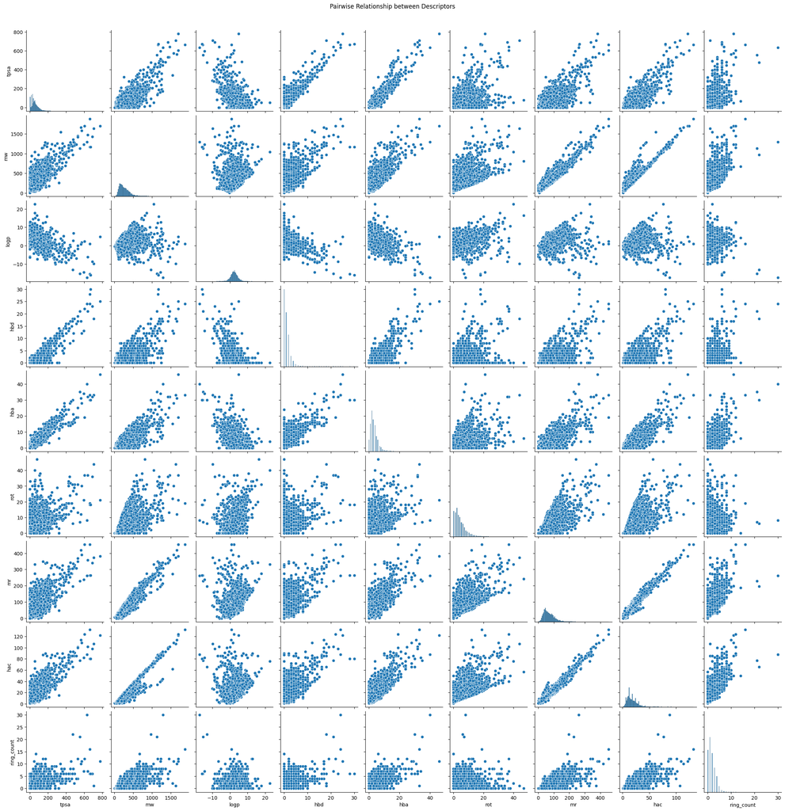

```python
sns.pairplot(df_tox[cols])

# Add title
plt.suptitle('Pairwise Relationship between Descriptors', y=1.02)

# Show plot
plt.show()
```

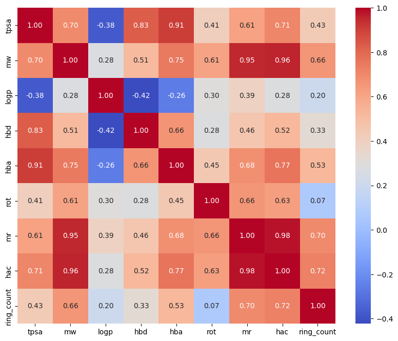

```python
corr_matrix = df_tox[cols].corr()

plt.figure(figsize=(10,8))
sns.heatmap(corr_matrix, annot=True, cmap='coolwarm', fmt=".2f")
plt.show()
```

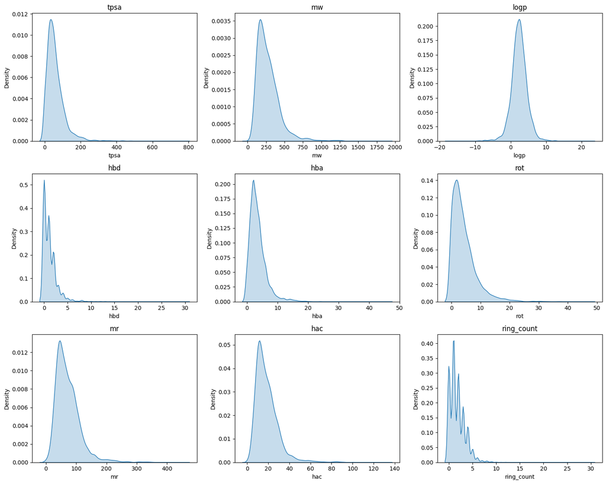

```python
fig, axes = plt.subplots(3, 3, figsize=(15, 12))
axes = axes.flatten()

for i, col in enumerate(cols):
    sns.kdeplot(data=df_tox, x=col, fill=True, ax=axes[i])
    axes[i].set_title(col)

# Remove empty subplots if cols < 9
for j in range(len(cols), 9):
    fig.delaxes(axes[j])

plt.tight_layout()
# plt.savefig(r'..\plots\1.Descriptor_without_normalization.png')
plt.show()
```

### 🔎 Key Observations

- Most molecular descriptors show right-skewed distributions, which is common for chemical property data.
- Properties such as molecular weight, TPSA, and rotatable bonds span a wide range of values.
- The presence of skewness suggests that direct use of raw values may negatively impact certain machine learning models.
- Visual inspection confirms the need for normalization to stabilize variance and improve model learning.

## 5. Power Transformation & Normalization

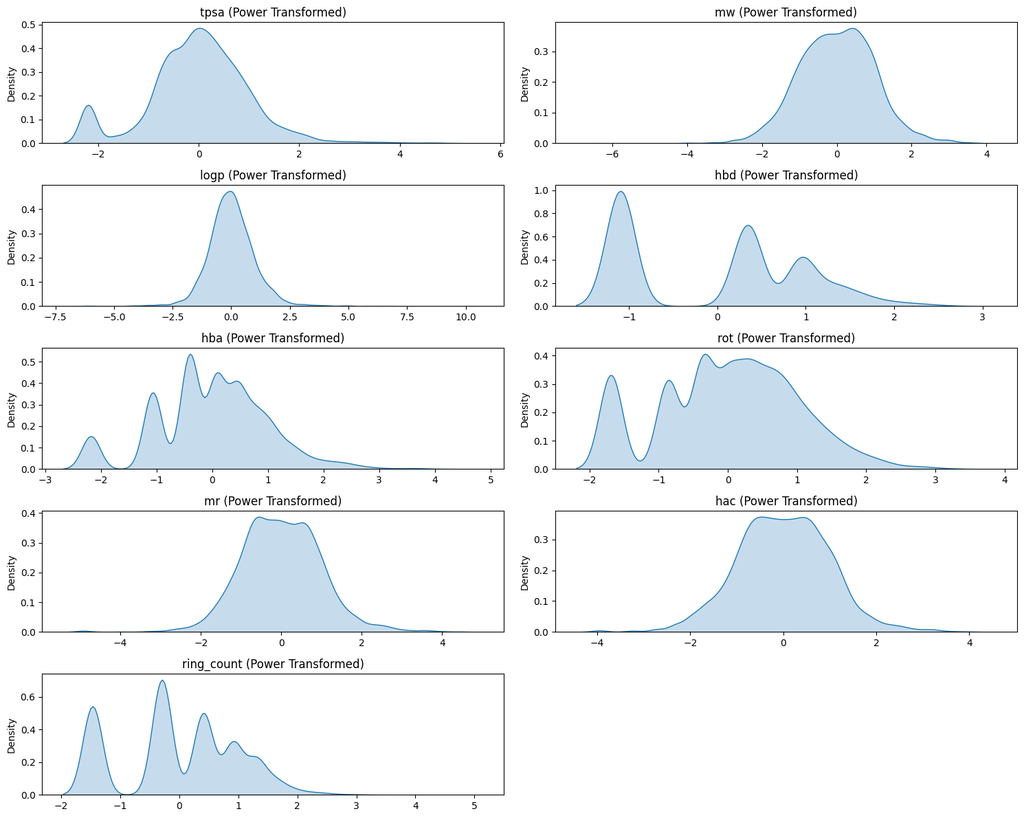

```python
n_rows = (len(cols) + 1) // 2
n_cols = 2

fig, axes = plt.subplots(n_rows, n_cols, figsize=(15, 12))
axes = axes.flatten()

for i, col in enumerate(cols):
    pt = PowerTransformer()
    transformed = pt.fit_transform(df_tox[[col]]).ravel()

    sns.kdeplot(x=transformed, fill=True, ax=axes[i])
    axes[i].set_title(f"{col} (Power Transformed)")

# remove unused axes
for j in range(len(cols), len(axes)):
    fig.delaxes(axes[j])

plt.tight_layout()
# plt.savefig(r'..\plots\2.Descriptor_with_normalization.png')
plt.show()
```

```python
# Converting fingerprint to numpy array
def to_array(fp):
    arr = np.zeros(fp.GetNumBits(), dtype=np.uint8)
    DataStructs.ConvertToNumpyArray(fp, arr)
    return arr

fp_array = df_tox['fp'].apply(to_array)

df_tox['fp'] = fp_array
```

## 6. Model Training & Evaluation

```python
# Tox21 binary classification targets
targets = ['NR-AR', 'NR-AR-LBD', 'NR-AhR', 'NR-Aromatase',
           'NR-ER', 'NR-ER-LBD', 'NR-PPAR-gamma',
           'SR-ARE', 'SR-ATAD5', 'SR-HSE', 'SR-MMP', 'SR-p53'
            ]

# Scalar molecular descriptors
scalar_cols = ['tpsa', 'mw', 'hbd', 'hba', 'rot',
               'logp', 'ring_count', #'mr', 'hac'
                ]
```

```python
models_config = {
    "LR": Pipeline([("scaler", StandardScaler()),("clf", LogisticRegression(max_iter=1000))]),
    "KNN": Pipeline([("scaler", StandardScaler()),("clf", KNeighborsClassifier(n_neighbors=5))]),
    "RF": RandomForestClassifier(random_state=24),
    "XGB": XGBClassifier(random_state=24),
    "LGBM_Bal": LGBMClassifier(class_weight="balanced", verbosity=-1, random_state=24),
    "LGBM_Unbal": LGBMClassifier(is_unbalance=True, verbosity=-1, random_state=24)
}
```

```python
MODEL_DIR = "../models"
os.makedirs(MODEL_DIR, exist_ok=True)
```

```python
results = {t: {} for t in targets}
best_models_store_normalize = {}


for target in targets:
    print(f"\n================ Target: {target} ================")

    df_sub = df_tox[df_tox[target].notna()]
    y = df_sub[target].values

    X_scalar = df_sub[scalar_cols].values
    X_fp = np.stack(df_sub["fp"].values)

    # ---------------- Train / Test Split ----------------
    Xs_train, Xs_test, Xfp_train, Xfp_test, y_train, y_test = train_test_split(
        X_scalar,
        X_fp,
        y,
        test_size=0.2,
        stratify=y,
        random_state=24
    )

    # ---------------- Power Transform (FIT ONLY ON TRAIN) ----------------
    pt = PowerTransformer(method="yeo-johnson")
    Xs_train_pt = pt.fit_transform(Xs_train)
    Xs_test_pt = pt.transform(Xs_test)

    # ---------------- Combine Scalar + FP ----------------
    X_train = np.hstack([Xs_train_pt, Xfp_train])
    X_test = np.hstack([Xs_test_pt, Xfp_test])

    best_f1 = -1
    best_model = None
    best_model_name = None

    for name, model in models_config.items():
        print(f"\n>>> Model: {name}")

        model.fit(X_train, y_train)
        y_pred = model.predict(X_test)

        # -------- Metrics --------
        report = classification_report(y_test, y_pred, digits=4)
        cm = confusion_matrix(y_test, y_pred)
        f1_class1 = f1_score(y_test, y_pred, pos_label=1)

        print("Classification Report:")
        print(report)

        print("Confusion Matrix:")
        print(cm)

        print(f"F1 (Class 1): {f1_class1:.4f}")

        results[target][name] = f1_class1

        if f1_class1 > best_f1:
            best_f1 = f1_class1
            best_model = model
            best_model_name = name

    # ---------------- Save Best Model + Transformer ----------------
    model_path = f"{MODEL_DIR}/{target}_best_model.joblib"
    transformer_path = f"{MODEL_DIR}/{target}_power_transformer.joblib"

    joblib.dump(best_model, model_path)
    joblib.dump(pt, transformer_path)

    best_models_store_normalize[target] = {
        "model_name": best_model_name,
        "model_path": model_path,
        "transformer_path": transformer_path,
        "best_f1_class1": best_f1
    }

    print(f"\n💾 Saved best model: {best_model_name}")
    print(f"🏆 Best F1 (Class 1): {best_f1:.4f}")
```

```
================ Target: NR-AR ================

>>> Model: LR
Classification Report:
              precision    recall  f1-score   support

         0.0     0.9714    0.9791    0.9753      1390
         1.0     0.4314    0.3548    0.3894        62

    accuracy                         0.9525      1452
   macro avg     0.7014    0.6670    0.6823      1452
weighted avg     0.9484    0.9525    0.9503      1452

Confusion Matrix:
[[1361   29]
 [  40   22]]
F1 (Class 1): 0.3894

>>> Model: KNN
Classification Report:
              precision    recall  f1-score   support

         0.0     0.9686    1.0000    0.9841      1390
         1.0     1.0000    0.2742    0.4304        62

    accuracy                         0.9690      1452
   macro avg     0.9843    0.6371    0.7072      1452
weighted avg     0.9700    0.9690    0.9604      1452

Confusion Matrix:
[[1390    0]
 [  45   17]]
F1 (Class 1): 0.4304

>>> Model: RF
Classification Report:
              precision    recall  f1-score   support

         0.0     0.9726    0.9971    0.9847      1390
         1.0     0.8519    0.3710    0.5169        62
```

[output cut: 1156 more lines]

```

         0.0     0.9651    0.9582    0.9616      1269
         1.0     0.4362    0.4824    0.4581        85

    accuracy                         0.9284      1354
   macro avg     0.7006    0.7203    0.7099      1354
weighted avg     0.9319    0.9284    0.9300      1354

Confusion Matrix:
[[1216   53]
 [  44   41]]
F1 (Class 1): 0.4581

💾 Saved best model: LGBM_Unbal
🏆 Best F1 (Class 1): 0.4581
```

```python
results_df_normalize = pd.DataFrame(results).T

numeric_cols = results_df_normalize.select_dtypes(include="number")

results_df_normalize["Best_Model"] = numeric_cols.idxmax(axis=1)
results_df_normalize["Best_CV_F1"] = numeric_cols.max(axis=1)

results_df_normalize.to_csv("results_with_normalize.csv", index=False)
display(results_df_normalize.sort_values("Best_CV_F1", ascending=False))
```

|  | LR | KNN | RF | XGB | LGBM_Bal | LGBM_Unbal | Best_Model | Best_CV_F1 |
| --- | --- | --- | --- | --- | --- | --- | --- | --- |
| SR-MMP | 0.545455 | 0.156098 | 0.477733 | 0.641745 | 0.649746 | 0.670103 | LGBM_Unbal | 0.670103 |
| NR-AR-LBD | 0.577320 | 0.400000 | 0.623377 | 0.666667 | 0.666667 | 0.652174 | XGB | 0.666667 |
| NR-AhR | 0.450331 | 0.130952 | 0.343750 | 0.489083 | 0.583333 | 0.573134 | LGBM_Bal | 0.583333 |
| SR-ARE | 0.381643 | 0.071066 | 0.271493 | 0.491103 | 0.520681 | 0.515366 | LGBM_Bal | 0.520681 |
| NR-AR | 0.389381 | 0.430380 | 0.516854 | 0.500000 | 0.452830 | 0.446602 | RF | 0.516854 |
| NR-ER-LBD | 0.400000 | 0.195122 | 0.391304 | 0.466019 | 0.475524 | 0.460432 | LGBM_Bal | 0.475524 |
| SR-p53 | 0.304878 | 0.067416 | 0.204082 | 0.319328 | 0.411429 | 0.458101 | LGBM_Unbal | 0.458101 |
| NR-ER | 0.337079 | 0.227027 | 0.321244 | 0.420091 | 0.425532 | 0.421687 | LGBM_Bal | 0.425532 |
| NR-Aromatase | 0.340426 | 0.179104 | 0.273973 | 0.317073 | 0.370370 | 0.408163 | LGBM_Unbal | 0.408163 |
| SR-HSE | 0.233577 | 0.209302 | 0.170732 | 0.326531 | 0.402878 | 0.354610 | LGBM_Bal | 0.402878 |
| NR-PPAR-gamma | 0.226415 | 0.102564 | 0.102564 | 0.244898 | 0.360656 | 0.354839 | LGBM_Bal | 0.360656 |
| SR-ATAD5 | 0.216867 | 0.163934 | 0.140351 | 0.181818 | 0.255319 | 0.229885 | LGBM_Bal | 0.255319 |

**Why Power Transformation?**

- Molecular descriptors are naturally right-skewed
- Linear models (LR) and distance-based models (KNN) assume normally distributed features
- Yeo-Johnson handles zero values (unlike Box-Cox)
- **Critical:** Fitted only on training data to prevent leakage

## Limitations & Future Work

- **Missing data:** 7-26% of labels missing per assay (handled by per-target modeling)
- **Class imbalance:** Minority class as low as 2.88% (addressed via F1 metric and balanced sampling)
- **External validation:** Models not tested on external datasets
- **Feature engineering:** Could explore 3D descriptors, graph neural networks, or transformer-based molecular embeddings

**Future improvements:**

- Multi-task learning to leverage correlations between assays
- Ensemble stacking of best models

## Project Conclusion

This project successfully built machine learning models to predict chemical toxicity across 12 different biological tests using molecular structures.

**What we did:**

- Converted 7,823 chemical formulas (SMILES) into numerical features that computers can understand
- Created two types of features: basic properties (like weight, size) and structural fingerprints (molecular patterns)
- Applied power transformation to make data more normally distributed, which helps models learn better
- Tested 6 different machine learning algorithms on each of the 12 toxicity tests
- Selected the best-performing model for each test based on F1 score (balances precision and recall)

**Challenges addressed:**

- **Missing labels:** 7-26% of molecules weren't tested for every assay - solved by building separate models for each target
- **Class imbalance:** Only 3-16% of molecules were toxic - handled using balanced sampling and F1 scoring
- **Feature scaling:** Different molecular properties had very different ranges - normalized them properly

**Real-world impact:** These models can now screen new chemicals for toxicity **before** expensive lab testing, speeding up drug discovery and chemical safety assessment. All models are saved and ready for deployment in production environments.

**Future improvements:**

- Test on external datasets to verify generalization
- Try advanced techniques like graph neural networks that directly learn from molecular structures
- Use multi-task learning to leverage relationships between different toxicity tests